# 2013-2022 EPL Season Analysis

Odinakachukwu Egwuekwe ,

# Objective:

This analysis delves into English Premier League statistics from 2013 to 2022, aiming to uncover trends over the past decade and discern possible potential implications for the future. ## Query used on the Dataset

#### This query calculates the number of away wins, home wins, draws and Win Ratio for each season in the English Premier League dataset

```
SELECT
  *,
  Round(((No_of_Away_Wins+No_of_Home_Wins)/380)*100,1) as Win_Ratio

FROM(
  SELECT
    Season,
    COUNTIF(Result_FullTime="A") AS No_of_Away_Wins,
    COUNTIF(Result_FullTime="H") AS No_of_Home_Wins,
    COUNTIF(Result_FullTime="D") As No_of_Draws

  FROM
    `sonic-falcon-404009.EPL_STATS.match_stats`
  WHERE
    Result_FullTime IN ("A", "H","D")
  GROUP BY
      Season
);
```

#### This query retrieves Home statistics about the top six football clubs (Manchester United, Manchester City, Chelsea, Liverpool, Arsenal, and Tottenham) in the English Premier League.

```
WITH Big_Six_Clubs AS (

    SELECT
      Season,
      Month,
      Home_Team,
      Away_Team,
      AwayGoals_FullTime,
      Result_FullTime

    FROM
      `sonic-falcon-404009.EPL_STATS.match_stats`

    WHERE
      Home_Team IN ("Man United","Man City","Chelsea","Liverpool","Arsenal","Tottenham")
  )

SELECT
   Season,
   SUM(AwayGoals_FullTime) as Goals_conceeded,
   COUNTIF(Result_FullTime='A') AS Home_losses

FROM
   Big_Six_Clubs

WHERE
  Away_Team != Home_Team

GROUP BY
  Season;
```

#### This query aggregates statistics for each season in the English Premier League, including total home goals, total away goals, total yellow cards, total red cards, total goals, average away goals, average home goals, and average goals (both home and away)

```
SELECT
  Season,
  SUM(HomeCard_Yellow+AwayCard_Yellow) as No_of_Yellow_Cards,
  SUM(HomeCard_Red+AwayCard_Red) as No_of_Red_Cards,
  Round(AVG(AwayGoals_FullTime),1) as Average_Awaygoal,
  Round(AVG(HomeGoals_FullTime),1) as Average_Homegoal,
  Round(AVG(HomeGoals_FullTime+AwayGoals_FullTime),1) as Average_Goals

FROM
  `sonic-falcon-404009.EPL_STATS.match_stats`

GROUP BY
   Season;
```

#### This query retrieves Home statistics about the Football clubs outside top six football teams (Manchester United, Manchester City, Chelsea, Liverpool, Arsenal, and Tottenham) in the English Premier League.

```
WITH Lower_Clubs AS (

   SELECT
      Season,
      Month,
      Home_Team,
      Away_Team,
      HomeGoals_FullTime,
      AwayGoals_FullTime,
      Result_FullTime


  FROM
     `sonic-falcon-404009.EPL_STATS.match_stats`

  WHERE
     Home_Team NOT IN ("Man United","Man City","Chelsea","Liverpool","Arsenal","Tottenham")

  )

  SELECT
    Season,
    SUM(HomeGoals_FullTime) as Goals_Scored,
    SUM(AwayGoals_FullTime) as Goals_conceeded,
    COUNTIF(Result_FullTime='H') AS Home_Wins,
    COUNTIF(Result_FullTime='D') AS Home_Draws,
    COUNTIF(Result_FullTime='A') AS Home_Loss



  FROM
    Lower_Clubs

  WHERE
    Away_Team != Home_Team

 GROUP BY
    Season
  ;
```

## Goal stats

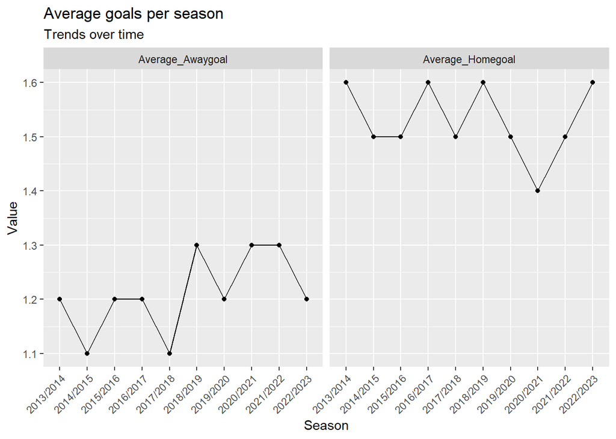

- *The 2020/2021* season is characterized by an almost equal average of goals per match for both away and home teams. This balance in scoring suggests a season where teams exhibited comparable offensive strength, resulting in a closely contested competition with similar goal-scoring performances whether playing at home or away. This equilibrium suggests a season characterized by balanced competition, where teams displayed comparable proficiency in scoring both at home and on the road.

## Win Stats

### Overall Win stats per season

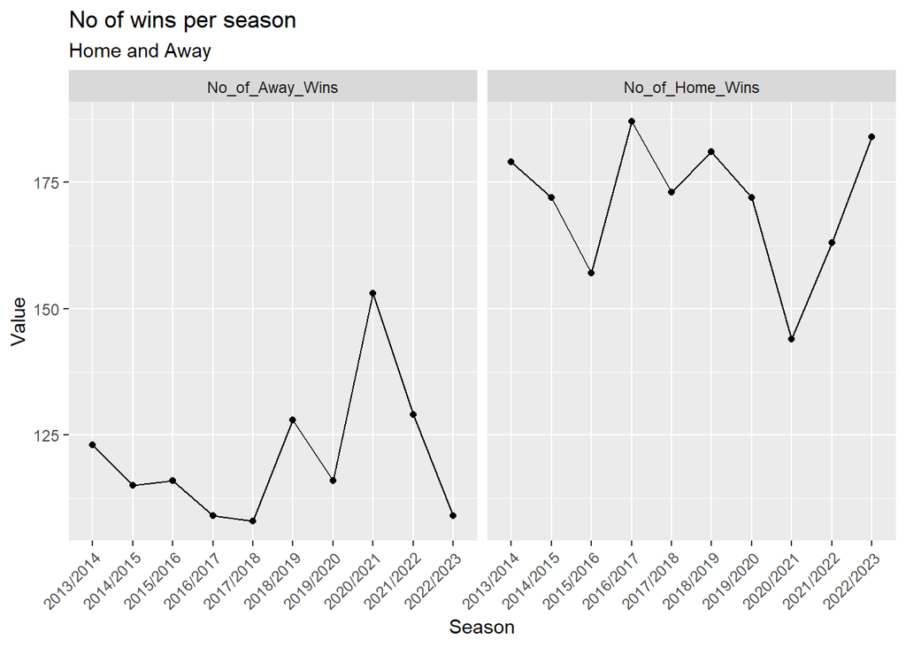

- Traditionally, Home Wins have consistently outnumbered Away Wins in most seasons, underscoring the influence of home-field advantage. However, the *2020/2021* season presented a noteworthy departure, with more Away Wins than Home Wins. This departure could be attributed to matches played amidst Covid-19 restrictions, leading to minimal or zero stadium capacity. This stark contrast highlights the pivotal role supporters play in a stadium, as their absence potentially disrupts the usual dynamics and impacts match outcomes. It reinforces the significance of fans in creating an electrifying atmosphere and influencing team performance, showcasing the irreplaceable connection between supporters and the vibrancy of the game.

### Win Ratio

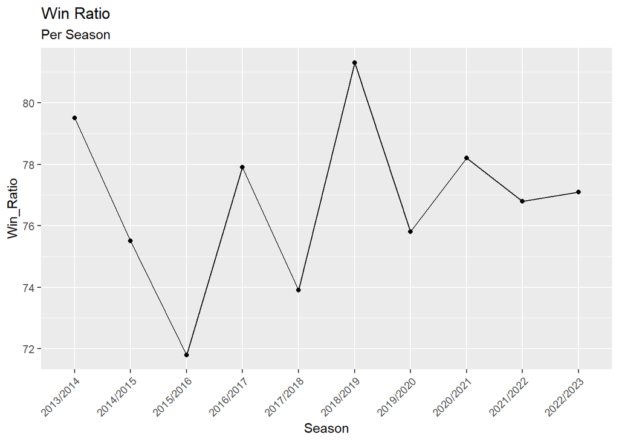

- In the dynamic landscape of the English Premier League, the win ratio has exhibited notable fluctuations over the years. During the *2015/2016* season, the win ratio reached its lowest point, approximately *72%*. However, a significant surge was witnessed in the *2018/2019* season, marking its peak at *81%*. Since then, the win ratio has demonstrated commendable stability, maintaining an average of *77%* across subsequent seasons. These variations highlight the competitive nature of the league and the ability of teams to adapt and perform consistently over time.

## Performance against the Big six teams

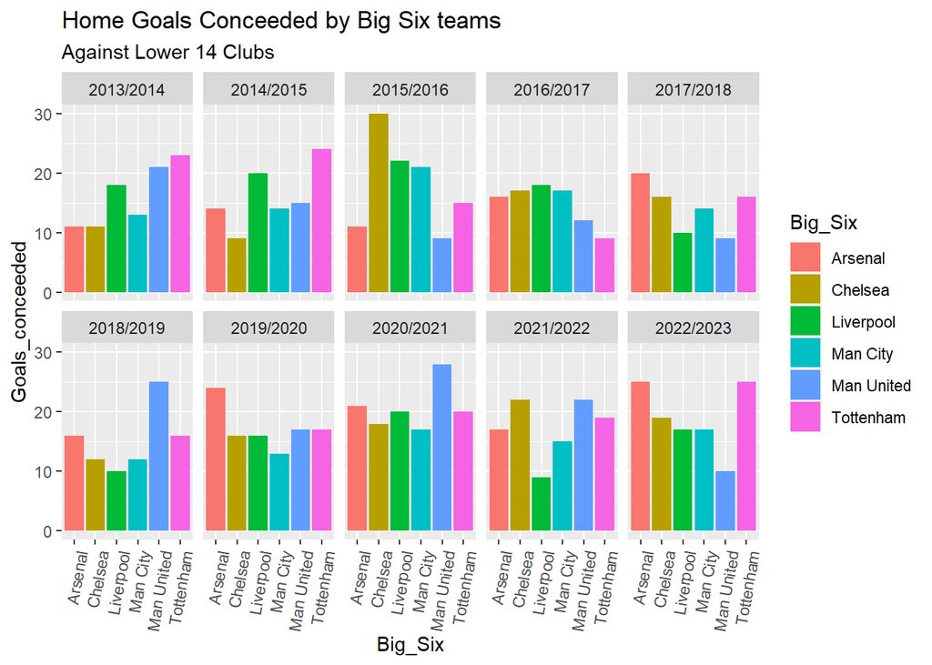

### Away performance Against the Big Six Clubs

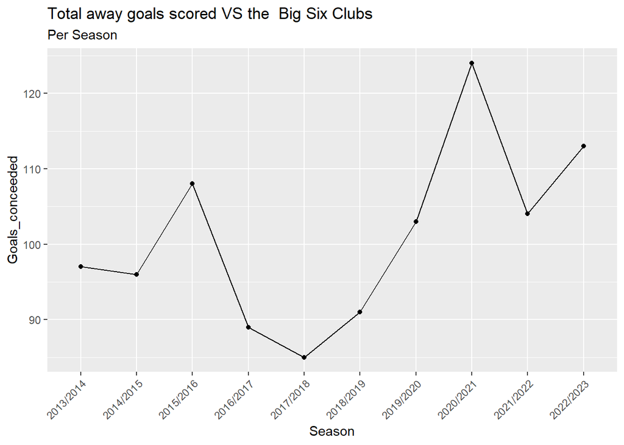

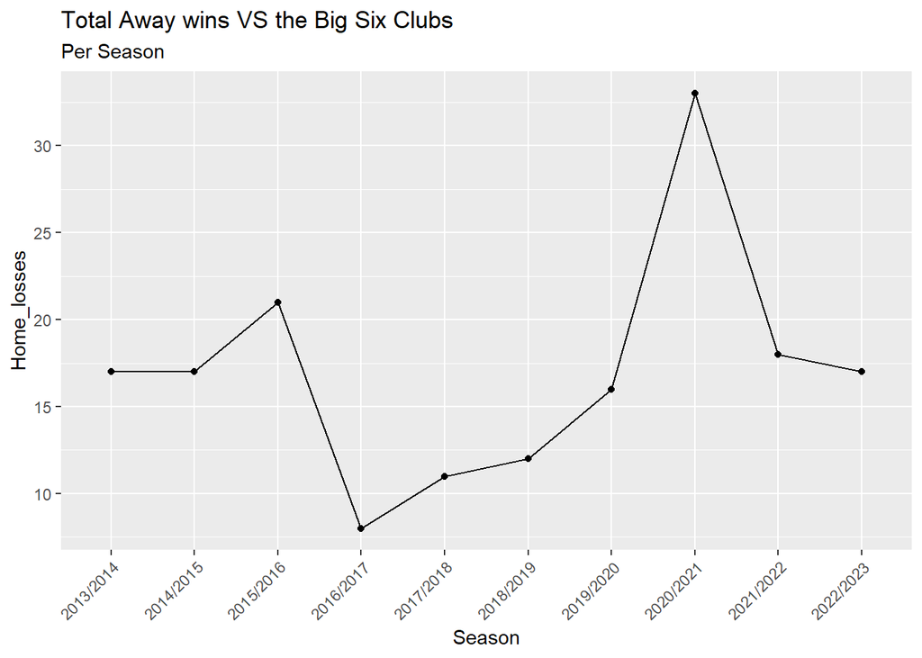

[figure not shown]